# individual2

Heather Moore

11/4/2020

```r
library(lubridate)
```

```r
library(ggplot2)
library(dplyr)
library(tidyverse)
library(maps)
```

Individual 2

```r
accident <- read.csv("https://raw.githubusercontent.com/xdaiISU/ds202materials/master/hwlabs/fars2017/accident.csv", stringsAsFactors = FALSE)

person <- read.csv("https://raw.githubusercontent.com/xdaiISU/ds202materials/master/hwlabs/fars2017/person.csv", stringsAsFactors = FALSE)
```

1.) Are there some days of the week where more accidents happen than the others (see FARS manual, use variable DAY_WEEK)? DAY_WEEK: records the day of the week on which the crash occurred.

```r
accident$Day_Name <- wday(accident$DAY_WEEK, label = TRUE)
acc2 <- accident %>% group_by(Day_Name) %>% summarize(dayweek = sum(DAY_WEEK))
```

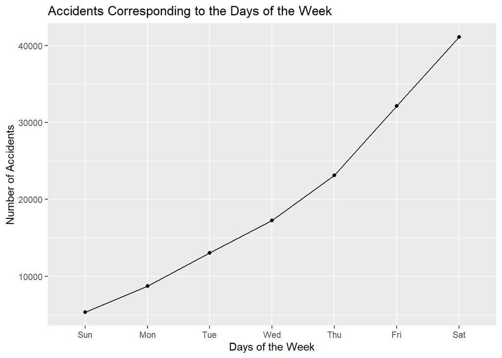

```r
acc2 %>% ggplot(aes(Day_Name, dayweek), width =700) + geom_point() + geom_line(group = 1) + labs(x = 'Days of the Week', y = 'Number of Accidents', title = 'Accidents Corresponding to the Days of the Week')
```

2.) Create a data frame containing the persons who are fatally hurt in the accidents (look up variable INJ_SEV)

```r
per2 <- person %>% filter(INJ_SEV == '4')
head(per2)
```

```
##   STATE ST_CASE VE_FORMS VEH_NO PER_NO STR_VEH COUNTY DAY MONTH HOUR MINUTE
## 1     1   10001        1      1      1       0     73  19     2   23     35
## 2     1   10002        1      1      1       0     89  14     2   14     59
## 3     1   10003        3      2      1       0    101  31     1   20     31
## 4     1   10004        1      1      1       0     73   1     1   16     55
## 5     1   10005        1      1      1       0     13   1     1   20      0
## 6     1   10006        2      1      1       0     49   6     1   18     40
##   RUR_URB FUNC_SYS HARM_EV MAN_COLL SCH_BUS MAKE MAK_MOD BODY_TYP MOD_YEAR
## 1       2        1      38        0       0   20   20421       15     2004
## 2       2        1       1        0       0   37   37402       14     2005
## 3       2        1      12        1       0    2    2404       14     2003
## 4       2        4      30        0       0   30   30046        4     2014
## 5       1        1      35        0       0   12   12471       34     2010
## 6       1        1      34        0       0   49   49032        4     1997
##   TOW_VEH SPEC_USE EMER_USE ROLLOVER IMPACT1 FIRE_EXP AGE SEX PER_TYP INJ_SEV
```

[output cut: 41 more lines]

3.) Create a data frame containing the most dangerous vehicle make in each state. The number of persons fatally hit in the vehicle make is used to assess the (non-)safety of a make. Make sure to handle the missing values appropriately. (look up variable MAKE)

```r
dangerous <- per2 %>%
  drop_na(MAKE) %>%
  group_by(STATE, MAKE) %>%
  summarise(fatal_acc = n()) %>%
  group_by(STATE) %>%
  filter(fatal_acc == max(fatal_acc))
head(dangerous)
```

```
## # A tibble: 6 x 3
## # Groups:   STATE [6]
##   STATE  MAKE fatal_acc
##   <int> <int>     <int>
## 1     1    12       138
## 2     2    12         9
## 3     4    20        88
## 4     5    20        88
## 5     6    49       351
## 6     8    12        63
```

4.Create a map, and label each state with the most dangerous vehicle. Discuss the definition of the most dangerous vehicle, and what you find from the map. (Hint: Read the description for the STATE and COUNTY columns in the FARS manual. The state & county codes are Geographic Locator Codes (GLCs) from the General Services Administration’s (GSA) publication. Use readxl::read_xlsx to read in the GLCs.)

```r
MakeCode <- read.csv('makeCodes.csv')
StateCode <- read.csv('stateCodes.csv')

StateCode$State<- tolower(StateCode$State)
StateCode$Codes <- as.numeric(StateCode$Codes)
dangerous$fatal_acc <- as.numeric(dangerous$fatal_acc)
dangerous$STATE <- as.numeric(dangerous$STATE)

states <- map_data("county")

states %>% rename("STATE" = "region")
```

[output not shown]

[output cut: 16653 more lines]

[figure not shown]

```r
All <- left_join(states, dangerous, by = c('order'='STATE'))
all2 <- left_join(All, MakeCode, by = c('MAKE' = "Codes"))

all2 %>% ggplot(aes(long,lat, label = Make)) + geom_polygon(aes(group = group)) + geom_text()
```